# Data 607 - Week 1 Assignment

### Data Exploration and Visualization

Now, I will perform some exploratory data analysis, starting with a pie chart to visualize the racial distribution of Republican candidates in New York who won their races. This will give us a better understanding of the diversity within the winning candidates.

```r
ny_rep_candidates
```

| gender | race | inc | inc chal | pos | dist | n_prim | rat_prim | insurrectionist | trump_endorse |
| --- | --- | --- | --- | --- | --- | --- | --- | --- | --- |
| Male | Black | No | No | Senator | N/A | 1 | 100% | FALSE | TRUE |
| Male | White | No | No | Governor | N/A | 196,874 | 43% | FALSE | TRUE |
| Male | White | No | No | Representative | 1 | 12,015 | 47% | FALSE | TRUE |
| Male | White | Yes | No | Representative | 2 | 9,902 | 53% | FALSE | TRUE |
| Male | White | No | No | Representative | 3 | 1 | 100% | FALSE | TRUE |
| Male | White | No | No | Representative | 4 | 1 | 100% | FALSE | TRUE |
| Male | White | No | No | Representative | 5 | 1 | 100% | FALSE | TRUE |
| Male | White | No | No | Representative | 6 | 1 | 100% | FALSE | TRUE |
| Male | Latino | No | No | Representative | 7 | 1 | 100% | FALSE | TRUE |
| Male | White | No | No | Representative | 8 | 1 | 100% | FALSE | TRUE |

[output cut: 16 more lines]

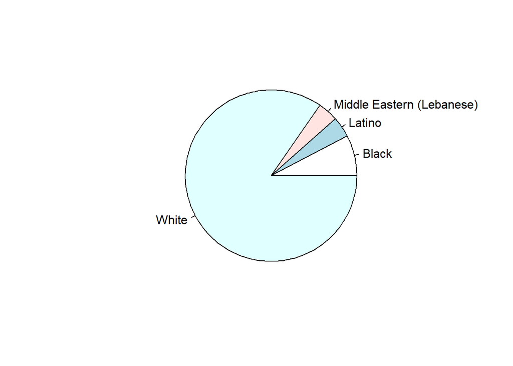

```r
#race distribution of NY Republican candidates that won in 2020

pie(table(ny_rep_candidates$race))
```

Barplot showing candidate incumbent count

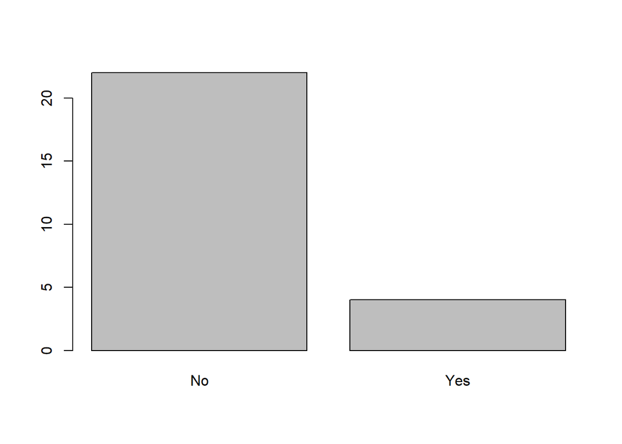

```r
#Was Candidate incumbent?

barplot(table(ny_rep_candidates$inc))
```

To measure the mean ratio of votes, I will first need to remove the `%` symbol from the values in the vote ratio column, as these values are currently stored as characters rather than numeric data. Once the `%` sign is removed, I can convert the values to a numeric format to perform calculations like the mean.

```r
without_percent=c()

for(i in ny_rep_candidates$rat_prim){
  i=substr(i, start=1, stop=nchar(i)-1)
  without_percent=append(without_percent,i)
}
without_percent
```

```
##  [1] "100" "43"  "47"  "53"  "100" "100" "100" "100" "100" "100" "100" "78"
## [13] "100" "67"  "100" "100" "75"  "100" "100" "100" "100" "57"  "51"  "54"
## [25] "100" "100"
```

Now that the `%` sign has been successfully removed from the vote ratio column, we can convert the values to numeric format. After this conversion, I’ll adjust the values to represent actual ratios by dividing them by 100, making them ready for further analysis.

```r
ny_rep_candidates$rat_prim=as.numeric(without_percent)

#Now lets make this an actual ratio

ny_rep_candidates$rat_prim=(ny_rep_candidates$rat_prim)/100
ny_rep_candidates
```

| gender | race | inc | inc chal | pos | dist | n_prim | rat_prim | insurrectionist | trump_endorse |
| --- | --- | --- | --- | --- | --- | --- | --- | --- | --- |
| Male | Black | No | No | Senator | N/A | 1 | 1.00 | FALSE | TRUE |
| Male | White | No | No | Governor | N/A | 196,874 | 0.43 | FALSE | TRUE |
| Male | White | No | No | Representative | 1 | 12,015 | 0.47 | FALSE | TRUE |
| Male | White | Yes | No | Representative | 2 | 9,902 | 0.53 | FALSE | TRUE |
| Male | White | No | No | Representative | 3 | 1 | 1.00 | FALSE | TRUE |
| Male | White | No | No | Representative | 4 | 1 | 1.00 | FALSE | TRUE |
| Male | White | No | No | Representative | 5 | 1 | 1.00 | FALSE | TRUE |
| Male | White | No | No | Representative | 6 | 1 | 1.00 | FALSE | TRUE |
| Male | Latino | No | No | Representative | 7 | 1 | 1.00 | FALSE | TRUE |
| Male | White | No | No | Representative | 8 | 1 | 1.00 | FALSE | TRUE |

[output cut: 16 more lines]

```r
#finally, lets measure the mean ratio of votes one during the primary
mean(ny_rep_candidates$rat_prim)
```

```
## [1] 0.8557692
```

85%

## Findings and Recommendations

This is a really robust data set. The 2022 election cycle was an interesting one. Right wing media and polls boasted about a red wave that was supposed to take over the house and senate that season. In reality, the results were complete opposite of what was expected.

There was an unexpected red wave in New York State, where a lot of republicans won seats in districts that weren’t expected to be republican. This is likely an effect of the change in electoral map from the previous season to the current. The current electoral map is gerrymandered to favor republicans. It would be interesting in the future to compare these results with the results of the previous election.

It would also be interesting to compare NY results vs results from other states to see if there were any differences.